# Preparing Data for HMA: How many samples are enough to train a multi-table synthesizer?

> **When to use this cookbook:** You're training a multi-table synthesizer and want to figure out how much of your data you actually need — trading off synthetic-data quality against training and sampling time.

One question many users ask is *how much data is enough* to train the synthesizer? Our general advice is to cycle through the following steps until your quality is acceptable for the time it takes to generate the synthetic data:

1. Start with a small sample size of training data (e.g. 1%)
2. Train an [`HMASynthesizer`](https://docs.sdv.dev/sdv/multi-table-data/modeling/synthesizers/hmasynthesizer) model
3. Measure how long it took for the model to train and synthesize
4. Evaluate the quality of the data using [`evaluate_quality`](https://docs.sdv.dev/sdv/multi-table-data/evaluation/data-quality)

If you want higher data quality and find the modeling and synthesis time acceptable, increase the sample size and run through steps 2 - 4 again.

In this tutorial, we'll show how sample size, run time, and data quality interact in one instance. To prepare, we performed these steps for the bank credit-card dataset (SDV's `financial` demo), iterating steps 2-4. We trained an HMASynthesizer model using 1%, 5%, 10%, 20%, 30%, 40%, and 50% samples of our data (anchored to the **account** table). Of the 4,500 accounts in the full dataset, we subsampled down to each proportion while preserving referential integrity across the linked tables. We then ran through each sample size 3 times, collecting the following information:

- We timed how long it took to fit the model and generate synthetic data at full scale *(note that the volume of data increases each time we increase the sample size).*
- We averaged the runtime and the overall quality score over the 3 runs.

```python
import warnings

warnings.filterwarnings('ignore')
```

## Getting to know the data

Before we start it's always a good idea to get to know the data you are working with. Here is a quick rundown of what each table represents in the dataset we are going to be using:

- **loan**: each row represents a bank loan, along with the account it's linked to
- **client**: each row represents a unique banking client
- **trans**: each row represents a financial transaction
- **account**: each row represents an account's static information
- **card**: each row represents an issued credit card, along with the account it is linked to
- **order**: each row represents the characteristics of a payment order
- **disp**: each row links together a client and an account

Here's a diagram that visualizes the relationships between these tables:

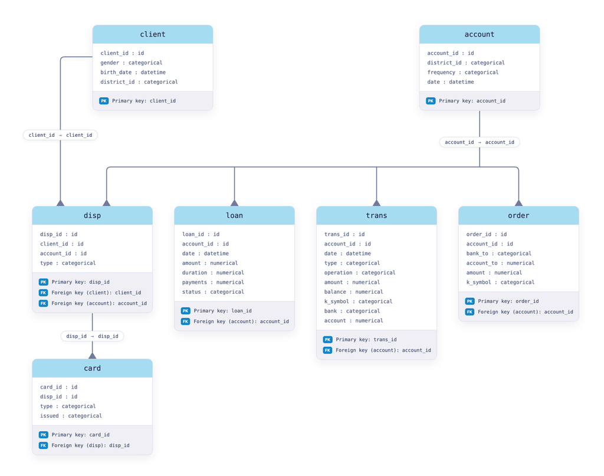

After we are familiar with the data we can load the `financial` demo and its corresponding metadata using `download_demo`.

```python
from sdv.datasets.demo import download_demo

real_data, multi_metadata = download_demo(
    modality='multi_table',
    dataset_name='financial',
)
```

The `financial` dataset also includes a small `district` table that `account` and `client` look up by `district_id`. We don't need it for this benchmark, so we'll drop it and treat the `district_id` columns as categorical.

```python
real_data.pop('district')
multi_metadata.remove_table('district')

multi_metadata.update_columns_metadata(
    table_name='account',
    column_metadata={'district_id': {'sdtype': 'categorical'}},
)
multi_metadata.update_columns_metadata(
    table_name='client',
    column_metadata={'district_id': {'sdtype': 'categorical'}},
)
```

Here's a peek at the `account` table — the main table we'll anchor our subsampling on.

```python
real_data['account'].head()
```

|  | account_id | district_id | frequency | date |
| --- | --- | --- | --- | --- |
| 0 | 1 | 18 | POPLATEK MESICNE | 1995-03-24 |
| 1 | 2 | 1 | POPLATEK MESICNE | 1993-02-26 |
| 2 | 3 | 5 | POPLATEK MESICNE | 1997-07-07 |
| 3 | 4 | 12 | POPLATEK MESICNE | 1996-02-21 |
| 4 | 5 | 15 | POPLATEK MESICNE | 1997-05-30 |

## Setting up the benchmark

The benchmark needs a couple of SDV imports plus a small lookup that maps a synthesizer name to its class.

```python
from sdv.evaluation.multi_table import evaluate_quality
from sdv.multi_table import HMASynthesizer, HSASynthesizer
from sdv.utils import poc
import time

SYNTHESIZER_CLASSES = {'HMA': HMASynthesizer, 'HSA': HSASynthesizer}
```

We benchmark each sample size with a single helper, `synthesize_using_random_subset_data`. For a given proportion it subsamples the data down to that fraction of the `account` table (keeping referential integrity with [`get_random_subset`](https://docs.sdv.dev/sdv/multi-table-data/data-preparation/cleaning-your-data#get_random_subset)), trains the chosen synthesizer (`'HMA'` or `'HSA'`), generates synthetic data at full scale, and records both the SDMetrics quality score and the runtime. It repeats this for several iterations and returns the per-iteration quality scores and runtimes, so we can average out run-to-run noise.

```python
def synthesize_using_random_subset_data(
    proportion, multi_table_data, main_table_name, metadata, synthesizer_type, iterations
):
    main_table_rows = round(len(multi_table_data[main_table_name]) * proportion)
    overall_quality_scores = []
    timings = []

    for _ in range(iterations):
        start_time = time.time()

        subsampled_data = poc.get_random_subset(
            multi_table_data,
            metadata,
            main_table_name=main_table_name,
            num_rows=main_table_rows,
            verbose=False,
        )

        synthesizer = SYNTHESIZER_CLASSES[synthesizer_type](metadata)
        synthesizer.fit(subsampled_data)
        synthetic_data = synthesizer.sample(1.0)
        timings.append(time.time() - start_time)

        quality_report = evaluate_quality(
            real_data=multi_table_data,
            synthetic_data=synthetic_data,
            metadata=metadata,
            verbose=False,
        )
        overall_quality_scores.append(quality_report.get_score())

    return overall_quality_scores, timings
```

Running that helper across every sample size gives a quality score and runtime for each. Let's walk through what we found, chart by chart.

First, let's plot the quality scores and see how they vary with different sample sizes.

## How does the quality of synthetic data improve as we add more training data?

```
hma_benchmark_results = {
    proportion: synthesize_using_random_subset_data(proportion, real_data, 'account', multi_metadata, 'HMA', 3)
    for proportion in [0.01, 0.05, 0.10, 0.20, 0.30, 0.40, 0.50]
}
```

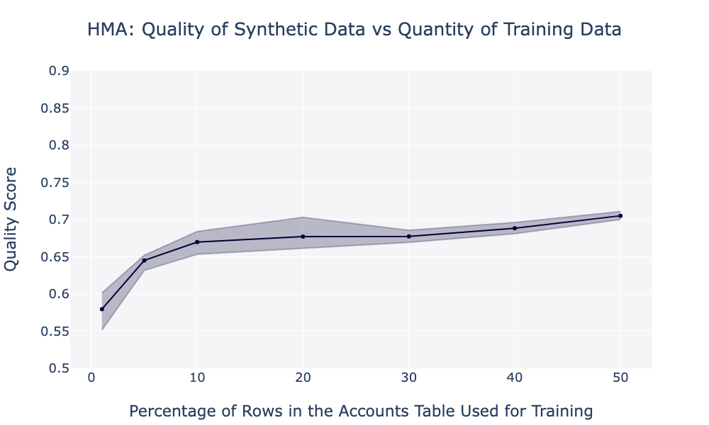

As you can see in the figure above, the biggest jump in quality score came from increasing the sample size (the number of rows used for training) from 1% of the original data to 5% of the original data. The average quality score jumped from 58.0% to 64.5%. Increasing the sample size to 10% of the original data resulted in an average quality score of 67.0%. After this, a visible plateau started to emerge.

Finally, using 40% and 50% of the original training data gave a marginal increase in quality score (to 68.8% and 70.5%) — but at what cost? The answer to this question is twofold:

- First — there may be reasons why you don't want to pull or provide access to that much real data. (After all, you are making synthetic data for a reason.) In that case, the question becomes whether or not we can build a reasonable model with a limited amount of data.
- Second — when using larger amounts of data, the time it takes for the model to train and synthesize may increase. To help us better understand whether it's worth it to keep increasing the sample size for small gains in quality, we'll now plot the average run time for each sample size:

```
hma_average_runtimes = {
    proportion: sum(runtimes) / len(runtimes) / 60
    for proportion, (_, runtimes) in hma_benchmark_results.items()
}
```

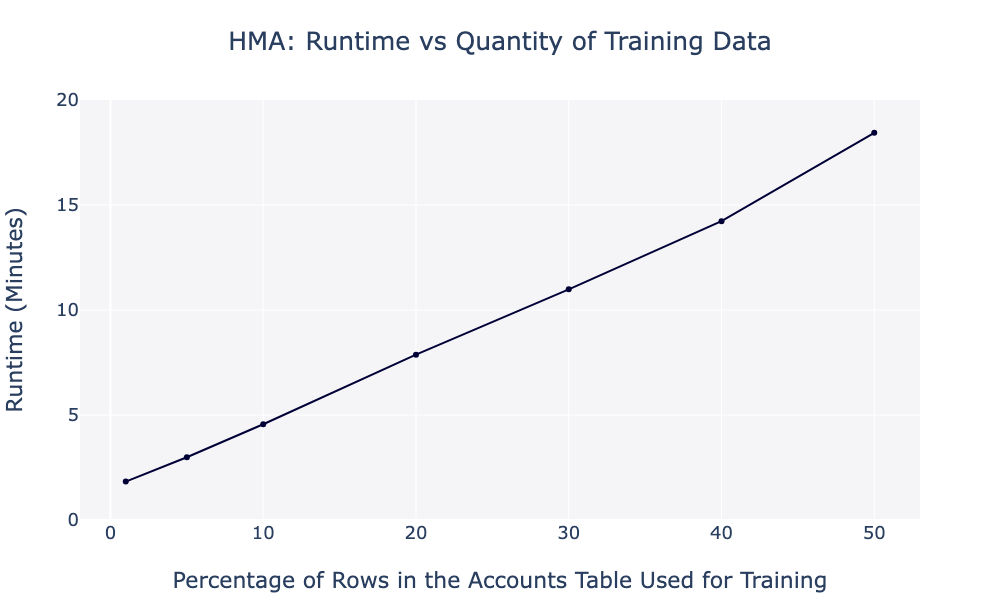

As you can see, if we stick to a 10% sample size, we observe a run time of 4.6 minutes. Increasing the sample size to 50% spikes the run time up to 18.4 minutes, with very little improvement in quality (67.0% to 70.5%).

Here's a table comparing average quality score and average run time using different sample sizes.

| **Sample Size** | **Quality Score (Average)** | **Run Time (Average)** |
| --- | --- | --- |
| 1% | 58.0% | 1.8 mins |
| 5% | 64.5% | 3.0 mins |
| **10%** | **67.0%** | **4.6 mins** |
| 20% | 67.7% | 7.9 mins |
| 30% | 67.7% | 11.0 mins |
| 40% | 68.8% | 14.2 mins |
| 50% | 70.5% | 18.4 mins |

> **Key takeaway:** For this dataset, roughly 10% of the data is the "sweet spot" — it keeps runtime low (~4.6 minutes) while landing within a few points of the best quality we measured (67.0% at 10% vs. 70.5% at 50%).

## Recommendations when working with your data

If you are facing this question, here are some recommendations from the SDV team.

- If you are able, we recommend experimenting using a similar iteration process to find your own "sweet spot" where the quality score starts to stabilize.
- If you are facing the question of how much real data to ask for from the team managing that data, and you can only ask once, our best bet is to pick a main table in the schema and request approximately 10% of the rows for that table. Don't forget to apply SDV utilities to get referentially sound data. In our experiments across other datasets, we found 10% was generally a good sample size.
- If you have access to a limited amount of data and cannot ask for more, you can still iterate as described above. If the quality score stabilizes, you will gain confidence in the subset you have, and if it does not, you will know how much to trust the model.

## Do these conclusions hold for all SDV synthesizers — for instance HSASynthesizer?

We've walked you through quality and run time considerations from the perspective of our free tool, HMASynthesizer. HMASynthesizer is recommended for learning and proofs of concept. SDV Enterprise users have access to another synthesizer, [`HSASynthesizer`](https://docs.sdv.dev/sdv/multi-table-data/modeling/synthesizers/hsasynthesizer), that can scale to handle more complex schemas and data volumes. In many cases, synthetic data generated using HSASynthesizer is also higher quality.

Let's train an HSASynthesizer model using 1%, 5%, 10%, 20%, 30%, 40%, 50%, and 100% samples of our bank credit-card dataset (once again anchored to the **account** table). Because HSA is so fast to train and use for data synthesis, you'll notice that we've added a 100% "sample" of the original data to this benchmarking exercise. Just like we did for HMA, we'll use 3 iterations and average the quality scores and run times.

First, here's a plot visualizing the average quality score achieved by different sample sizes of training data.

```
hsa_benchmark_results = {
    proportion: synthesize_using_random_subset_data(proportion, real_data, 'account', multi_metadata, 'HSA', 3)
    for proportion in [0.01, 0.05, 0.10, 0.20, 0.30, 0.40, 0.50, 1.0]
}
```

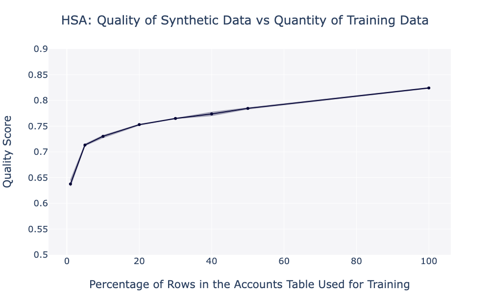

Here's a plot with average quality scores for HMA and HSA, so we can compare them more easily.

```
hma_average_quality = {
    proportion: sum(quality_scores) / len(quality_scores)
    for proportion, (quality_scores, _) in hma_benchmark_results.items()
}
hsa_average_quality = {
    proportion: sum(quality_scores) / len(quality_scores)
    for proportion, (quality_scores, _) in hsa_benchmark_results.items()
}
```

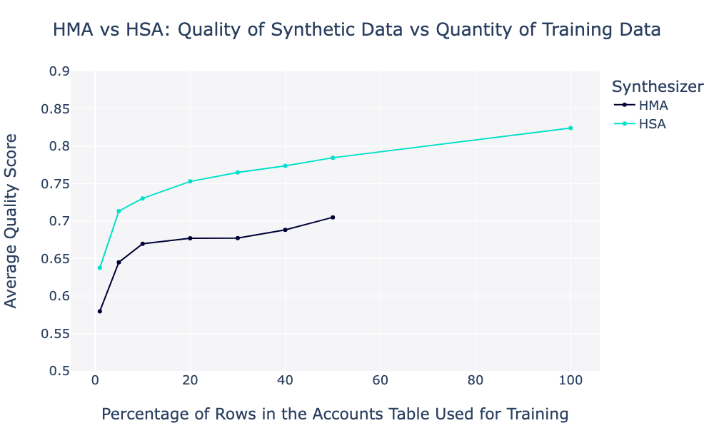

From the comparison, you'll immediately notice a few differences.

- HMA needed about 50% of the original training data to achieve an average quality score of 70%, while HSA needed less than 5%.
- HMA's quality scores had non-trivial uncertainty ranges while HSA's uncertainty ranges are too small to even show up in a chart of this scale.

Let's now visualize the average run times for HSASynthesizer.

```
hsa_average_runtimes = {
    proportion: sum(runtimes) / len(runtimes) / 60
    for proportion, (_, runtimes) in hsa_benchmark_results.items()
}
```

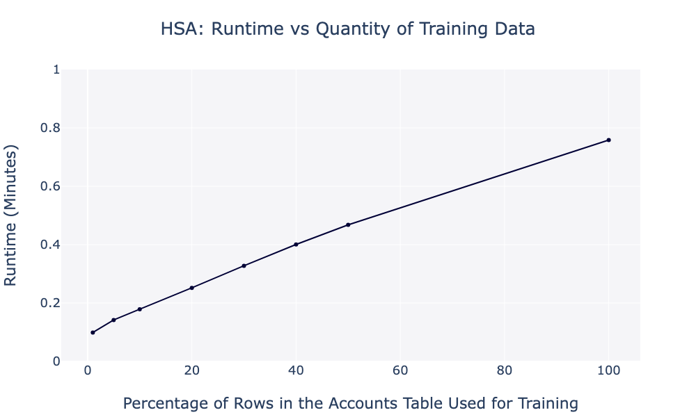

And now let's compare HSA with HMA.

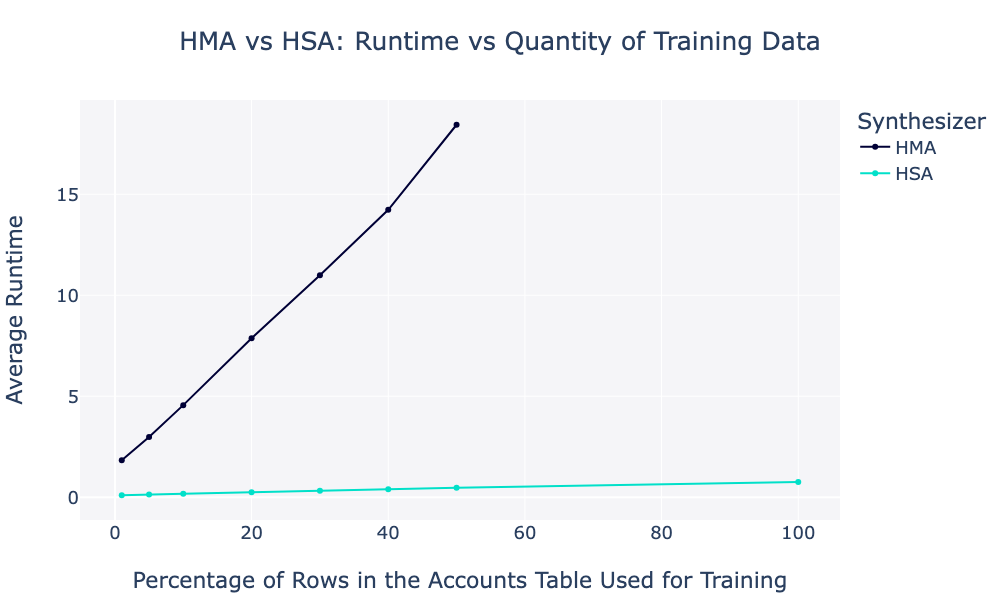

HSASynthesizer is *significantly* faster than HMASynthesizer:

- Even using 100% of the training data (in this case, 1,079,603 rows across all tables), HSA takes under 1 minute to fit and synthesize.
- HMA's *lowest* run time (~1.8 minutes) exceeds HSA's *highest* run time (~0.8 minutes)

| **Sample Size** | **Quality Score (Average)** | **Run Time (Average)** |
| --- | --- | --- |
| 1% | 63.8% | 0.1 mins |
| 5% | 71.3% | 0.1 mins |
| 10% | 73.0% | 0.2 mins |
| 20% | 75.3% | 0.3 mins |
| 30% | 76.5% | 0.3 mins |
| 40% | 77.4% | 0.4 mins |
| 50% | 78.5% | 0.5 mins |
| 100% | 82.4% | 0.8 mins |

Our hope with these benchmarks is to showcase how HMASynthesizer acts as an effective solution for proof of concept synthetic data projects — and when you need peak quality and performance for production, HSASynthesizer is the natural next step.

## Conclusion

In this tutorial, we worked with our bank credit-card dataset, taking training data at many different sample sizes and using it to train HMASynthesizer. We clocked runtime and used SDMetrics to measure quality for different sample sizes, comparing our results to help you build intuition around the amount of training data you might need. We ended with a side-by-side comparison of our HMA and HSA synthesizers to showcase the performance and quality upgrades you can expect to achieve with SDV Enterprise.

To scale to larger, more complex schemas, try the [HSASynthesizer](https://docs.sdv.dev/sdv/multi-table-data/modeling/synthesizers/hsasynthesizer), or explore the rest of the [SDV documentation](https://docs.sdv.dev/sdv/).